# 01_eda

## Objetivo del análisis exploratorio (EDA)

El objetivo del presente análisis exploratorio de datos es comprender en profundidad la estructura, calidad y características del dataset utilizado, así como identificar patrones preliminares relevantes para la predicción del reingreso hospitalario a 30 días.

De forma específica, este EDA persigue:

- Analizar la distribución de la variable objetivo y evaluar el posible desbalance de clases.
- Identificar problemas de calidad de datos, como valores ausentes, codificaciones inconsistentes o variables irrelevantes.
- Explorar la relación entre variables clínicas y administrativas con el evento de reingreso.
- Detectar posibles riesgos metodológicos, como data leakage o dependencia entre observaciones.
- Obtener información que permita guiar las decisiones de preprocesamiento y modelado posteriores.

Es importante destacar que esta fase tiene carácter exploratorio, por lo que no se aplicarán transformaciones definitivas sobre los datos, reservando dichas operaciones para la fase de preprocesamiento.

## Imports y configuración

En la siguiente celda importaremos y pondremos las configuraciones iniciales para el análisis exploratorio (EDA)

```python
import pandas as pd
import numpy as np

import matplotlib.pyplot as plt
import seaborn as sns

import missingno as msno

pd.set_option('display.max_columns', None)
sns.set(style="whitegrid")
```

## Carga del dataset

Se procede a cargar el conjunto de datos correspondiente a pacientes diabéticos hospitalizados en Estados Unidos entre 1999 y 2008. Este dataset contiene información clínica y administrativa a nivel de episodio hospitalario.

En esta fase inicial se verifica la correcta carga de los datos y se realiza una inspección preliminar de su estructura.

```python
df = pd.read_csv("../data/raw/diabetic_data.csv")

print(f"Shape: {df.shape}")
df.head()
```

```
Shape: (101766, 50)
```

|  | encounter_id | patient_nbr | race | gender | age | weight | admission_type_id | discharge_disposition_id | admission_source_id | time_in_hospital | payer_code | medical_specialty | num_lab_procedures | num_procedures | num_medications | number_outpatient | number_emergency | number_inpatient | diag_1 | diag_2 | diag_3 | number_diagnoses | max_glu_serum | A1Cresult | metformin | repaglinide | nateglinide | chlorpropamide | glimepiride | … |
| --- | --- | --- | --- | --- | --- | --- | --- | --- | --- | --- | --- | --- | --- | --- | --- | --- | --- | --- | --- | --- | --- | --- | --- | --- | --- | --- | --- | --- | --- | --- |
| 0 | 2278392 | 8222157 | Caucasian | Female | [0-10) | ? | 6 | 25 | 1 | 1 | ? | Pediatrics-Endocrinology | 41 | 0 | 1 | 0 | 0 | 0 | 250.83 | ? | ? | 1 | NaN | NaN | No | No | No | No | No | … |
| 1 | 149190 | 55629189 | Caucasian | Female | [10-20) | ? | 1 | 1 | 7 | 3 | ? | ? | 59 | 0 | 18 | 0 | 0 | 0 | 276 | 250.01 | 255 | 9 | NaN | NaN | No | No | No | No | No | … |
| 2 | 64410 | 86047875 | AfricanAmerican | Female | [20-30) | ? | 1 | 1 | 7 | 2 | ? | ? | 11 | 5 | 13 | 2 | 0 | 1 | 648 | 250 | V27 | 6 | NaN | NaN | No | No | No | No | No | … |
| 3 | 500364 | 82442376 | Caucasian | Male | [30-40) | ? | 1 | 1 | 7 | 2 | ? | ? | 44 | 1 | 16 | 0 | 0 | 0 | 8 | 250.43 | 403 | 7 | NaN | NaN | No | No | No | No | No | … |
| 4 | 16680 | 42519267 | Caucasian | Male | [40-50) | ? | 1 | 1 | 7 | 1 | ? | ? | 51 | 0 | 8 | 0 | 0 | 0 | 197 | 157 | 250 | 5 | NaN | NaN | No | No | No | No | No | … |

## Estructura general del dataset

En esta sección se analiza la estructura del dataset, incluyendo:

- Número de observaciones y variables
- Tipos de datos (numéricos, categóricos)
- Presencia de variables con alta cardinalidad
- Posibles inconsistencias en la codificación

Este análisis permite identificar variables que pueden requerir tratamiento específico en fases posteriores, como codificación de variables categóricas o eliminación de columnas irrelevantes (por ejemplo, identificadores únicos).

```python
df.info()
```

```
<class 'pandas.DataFrame'>
RangeIndex: 101766 entries, 0 to 101765
Data columns (total 50 columns):
 #   Column                    Non-Null Count   Dtype
---  ------                    --------------   -----
 0   encounter_id              101766 non-null  int64
 1   patient_nbr               101766 non-null  int64
 2   race                      101766 non-null  str
 3   gender                    101766 non-null  str
 4   age                       101766 non-null  str
 5   weight                    101766 non-null  str
 6   admission_type_id         101766 non-null  int64
 7   discharge_disposition_id  101766 non-null  int64
 8   admission_source_id       101766 non-null  int64
 9   time_in_hospital          101766 non-null  int64
```

[output cut: 42 more lines]

```python
df.describe(include='all').T.head(20)
```

|  | count | unique | top | freq | mean | std | min | 25% | 50% | 75% | max |
| --- | --- | --- | --- | --- | --- | --- | --- | --- | --- | --- | --- |
| encounter_id | 101766.0 | NaN | NaN | NaN | 165201645.622978 | 102640295.983457 | 12522.0 | 84961194.0 | 152388987.0 | 230270887.5 | 443867222.0 |
| patient_nbr | 101766.0 | NaN | NaN | NaN | 54330400.694947 | 38696359.346534 | 135.0 | 23413221.0 | 45505143.0 | 87545949.75 | 189502619.0 |
| race | 101766 | 6 | Caucasian | 76099 | NaN | NaN | NaN | NaN | NaN | NaN | NaN |
| gender | 101766 | 3 | Female | 54708 | NaN | NaN | NaN | NaN | NaN | NaN | NaN |
| age | 101766 | 10 | [70-80) | 26068 | NaN | NaN | NaN | NaN | NaN | NaN | NaN |
| weight | 101766 | 10 | ? | 98569 | NaN | NaN | NaN | NaN | NaN | NaN | NaN |
| admission_type_id | 101766.0 | NaN | NaN | NaN | 2.024006 | 1.445403 | 1.0 | 1.0 | 1.0 | 3.0 | 8.0 |
| discharge_disposition_id | 101766.0 | NaN | NaN | NaN | 3.715642 | 5.280166 | 1.0 | 1.0 | 1.0 | 4.0 | 28.0 |
| admission_source_id | 101766.0 | NaN | NaN | NaN | 5.754437 | 4.064081 | 1.0 | 1.0 | 7.0 | 7.0 | 25.0 |
| time_in_hospital | 101766.0 | NaN | NaN | NaN | 4.395987 | 2.985108 | 1.0 | 2.0 | 4.0 | 6.0 | 14.0 |
| payer_code | 101766 | 18 | ? | 40256 | NaN | NaN | NaN | NaN | NaN | NaN | NaN |
| medical_specialty | 101766 | 73 | ? | 49949 | NaN | NaN | NaN | NaN | NaN | NaN | NaN |
| num_lab_procedures | 101766.0 | NaN | NaN | NaN | 43.095641 | 19.674362 | 1.0 | 31.0 | 44.0 | 57.0 | 132.0 |
| num_procedures | 101766.0 | NaN | NaN | NaN | 1.33973 | 1.705807 | 0.0 | 0.0 | 1.0 | 2.0 | 6.0 |
| num_medications | 101766.0 | NaN | NaN | NaN | 16.021844 | 8.127566 | 1.0 | 10.0 | 15.0 | 20.0 | 81.0 |
| number_outpatient | 101766.0 | NaN | NaN | NaN | 0.369357 | 1.267265 | 0.0 | 0.0 | 0.0 | 0.0 | 42.0 |
| number_emergency | 101766.0 | NaN | NaN | NaN | 0.197836 | 0.930472 | 0.0 | 0.0 | 0.0 | 0.0 | 76.0 |
| number_inpatient | 101766.0 | NaN | NaN | NaN | 0.635566 | 1.262863 | 0.0 | 0.0 | 0.0 | 1.0 | 21.0 |
| diag_1 | 101766 | 717 | 428 | 6862 | NaN | NaN | NaN | NaN | NaN | NaN | NaN |
| diag_2 | 101766 | 749 | 276 | 6752 | NaN | NaN | NaN | NaN | NaN | NaN | NaN |

## Conclusiones sobre la estructura del dataset

En relación con las variables de identificación, se dispone de dos campos clave: `encounter_id` y `patient_nbr`, que permiten distinguir episodios individuales y vincular múltiples ingresos de un mismo paciente. Esta característica resulta especialmente relevante para el estudio del reingreso hospitalario, ya que posibilita reconstruir la trayectoria asistencial del paciente a lo largo del tiempo. No obstante, la estructura del dataset no incorpora explícitamente variables temporales como fechas de ingreso o alta, lo que limita la reconstrucción exacta de la secuencia temporal de eventos y constituye una diferencia relevante respecto a datasets administrativos reales como el CMBD.

En cuanto a las variables demográficas, el dataset incluye información sobre sexo (`gender`) y edad (`age`), esta última codificada en intervalos categóricos. Esta discretización simplifica el análisis pero implica una pérdida de granularidad que puede afectar a la capacidad predictiva del modelo. Asimismo, se observa una distribución no uniforme de estas variables, con predominio de pacientes en rangos de edad avanzada, lo que puede reflejar un sesgo poblacional hacia pacientes crónicos.

Desde el punto de vista clínico, el dataset incorpora diagnósticos principales y secundarios (`diag_1`, `diag_2`, `diag_3`) con una elevada cardinalidad (más de 700 categorías), lo que representa un reto significativo para su codificación y utilización en modelos de machine learning. Además, se dispone de variables relacionadas con la actividad clínica, como el número de procedimientos (`num_procedures`), pruebas de laboratorio (`num_lab_procedures`) y medicación (`num_medications`), que actúan como proxies de la complejidad clínica del paciente.

En el ámbito administrativo, se incluyen variables relevantes como tipo de ingreso (`admission_type_id`), tipo de alta (`discharge_disposition_id`) y duración de la estancia (`time_in_hospital`). Estas variables son especialmente relevantes en la literatura sobre predicción de reingresos, ya que reflejan tanto la gravedad del episodio como aspectos organizativos del sistema sanitario. No obstante, algunas variables como `medical_specialty` o `payer_code` presentan un elevado número de valores faltantes (codificados como `"?"`) y una alta cardinalidad, lo que puede limitar su utilidad en el modelado.

Por otro lado, el dataset incluye variables de utilización de recursos sanitarios previos (`number_outpatient`, `number_emergency`, `number_inpatient`), que aportan información longitudinal indirecta sobre el historial del paciente. Si bien estas variables pueden ser altamente predictivas, también introducen un riesgo potencial de data leakage si no se garantiza que reflejan únicamente información disponible en el momento de la predicción.

En conjunto, el dataset presenta una estructura rica y multidimensional, adecuada para el desarrollo de modelos predictivos, pero con limitaciones importantes que deben ser consideradas. Entre ellas destacan la ausencia de información temporal explícita, la alta cardinalidad de variables categóricas, la presencia de valores faltantes no estándar y la falta de variables clínicas detalladas o determinantes sociales. Estas características condicionarán las decisiones de preprocesamiento y modelado, así como la interpretabilidad y generalización de los resultados obtenidos.

### Implicaciones para el preprocesamiento

Las características estructurales del dataset implican la necesidad de un preprocesamiento cuidadoso y orientado a preservar la validez del modelo. En primer lugar, será necesario tratar explícitamente los valores faltantes codificados como `"?"`, diferenciando entre variables candidatas a imputación y aquellas cuya elevada proporción de missing aconseje su exclusión. Asimismo, la alta cardinalidad de variables categóricas, especialmente en diagnósticos y especialidades médicas, requerirá estrategias de reducción de dimensionalidad o agrupación clínica para evitar problemas de sobreajuste y complejidad computacional. La codificación de variables como edad en intervalos también deberá ser considerada, evaluando si su transformación mejora la capacidad predictiva. Por otro lado, las variables de utilización previa de recursos sanitarios deberán analizarse cuidadosamente para evitar la introducción de data leakage, garantizando que únicamente reflejan información disponible en el momento del alta. Finalmente, será necesario diseñar un pipeline de preprocesamiento reproducible que permita aplicar de forma consistente estas transformaciones en las fases de entrenamiento y validación del modelo.

## Definición y análisis de la variable objetivo

La variable original `readmitted` presenta tres categorías:

- `<30`: reingreso en menos de 30 días
- `>30`: reingreso después de 30 días
- `NO`: sin reingreso

Para alinear el problema con el objetivo del estudio, se transforma en una variable binaria:

- 1 → reingreso en ≤ 30 días
- 0 → no reingreso en ese periodo

Esta transformación implica una simplificación del problema, ya que no se distingue entre pacientes que reingresan después de 30 días y aquellos que no reingresan. No obstante, esta decisión es coherente con la literatura, donde el reingreso a 30 días se utiliza como indicador estándar de calidad asistencial.

Asimismo, se analiza la distribución de la variable objetivo para evaluar el grado de desbalanceo, lo cual tiene implicaciones directas en el diseño del modelo y en la selección de métricas de evaluación.

```python
df['readmitted'].value_counts()
```

```
readmitted
NO     54864
>30    35545
<30    11357
Name: count, dtype: int64
```

```python
df['readmit_30'] = (df['readmitted'] == '<30').astype(int)

df['readmit_30'].value_counts(normalize=True)
```

```
readmit_30
0    0.888401
1    0.111599
Name: proportion, dtype: float64
```

## Conclusiones sobre la variable objetivo

La variable objetivo original `readmitted` presenta tres categorías: pacientes sin reingreso (`NO`), pacientes con reingreso posterior a 30 días (`>30`) y pacientes con reingreso en menos de 30 días (`<30`). La distribución observada muestra un predominio claro de la categoría sin reingreso (aproximadamente 54% de los casos), seguida de reingresos tardíos (≈35%) y, en menor medida, reingresos tempranos (≈11%).

Para los fines del presente estudio, la variable se ha transformado en una variable binaria (`readmit_30`), donde se considera evento positivo únicamente el reingreso en menos de 30 días. Esta decisión permite alinear el problema con la literatura clínica, donde el reingreso a 30 días se utiliza como indicador estándar de calidad asistencial. No obstante, esta transformación implica la pérdida de información potencialmente relevante, ya que no se distingue entre pacientes con reingresos tardíos y aquellos que no reingresan.

El análisis de la variable binaria resultante pone de manifiesto un desbalance significativo de clases, con aproximadamente un 11,16% de casos positivos frente a un 88,84% de casos negativos. Este desequilibrio tiene implicaciones directas en el modelado, ya que los algoritmos de clasificación tienden a favorecer la clase mayoritaria, lo que puede derivar en modelos con alta precisión aparente pero baja capacidad para identificar correctamente los casos de interés.

Desde el punto de vista metodológico, este desbalance justifica la necesidad de utilizar métricas de evaluación más informativas que la accuracy, como el recall, la precisión o el F1-score, así como la posible aplicación de técnicas específicas de tratamiento del desbalanceo. Asimismo, refuerza la importancia de definir adecuadamente el umbral de decisión del modelo en función del contexto clínico, donde los falsos negativos (no identificar a un paciente de alto riesgo) pueden tener un impacto más relevante que los falsos positivos.

En conjunto, la variable objetivo presenta una formulación coherente con el problema de estudio, pero introduce retos importantes relacionados con la pérdida de información y el desbalance de clases, que deberán ser abordados cuidadosamente en las fases posteriores del análisis.

## Análisis de valores ausentes

En este dataset, los valores ausentes no se representan únicamente como valores nulos (`NaN`), sino también mediante el símbolo `"?"`, lo cual requiere un tratamiento específico.

Se realiza una transformación para unificar la representación de valores faltantes y se calcula el porcentaje de valores ausentes por variable.

Este análisis permite:

- Identificar variables con alta proporción de valores faltantes que podrían ser eliminadas.
- Detectar patrones de missing no aleatorio.
- Evaluar la viabilidad de técnicas de imputación en fases posteriores.

Es importante destacar que la gestión de valores ausentes puede introducir sesgos si no se realiza de forma adecuada, especialmente cuando los datos no son Missing Completely At Random (MCAR).

```python
df = df.replace("?", np.nan)

missing = df.isnull().mean().sort_values(ascending=False)
missing.head(20)
```

```
weight                      0.968585
max_glu_serum               0.947468
A1Cresult                   0.832773
medical_specialty           0.490822
payer_code                  0.395574
race                        0.022336
diag_3                      0.013983
diag_2                      0.003518
diag_1                      0.000206
patient_nbr                 0.000000
encounter_id                0.000000
time_in_hospital            0.000000
admission_source_id         0.000000
num_procedures              0.000000
num_lab_procedures          0.000000
admission_type_id           0.000000
discharge_disposition_id    0.000000
age                         0.000000
gender                      0.000000
number_inpatient            0.000000
dtype: float64
```

```python
missing[missing > 0.3]
```

```
weight               0.968585
max_glu_serum        0.947468
A1Cresult            0.832773
medical_specialty    0.490822
payer_code           0.395574
dtype: float64
```

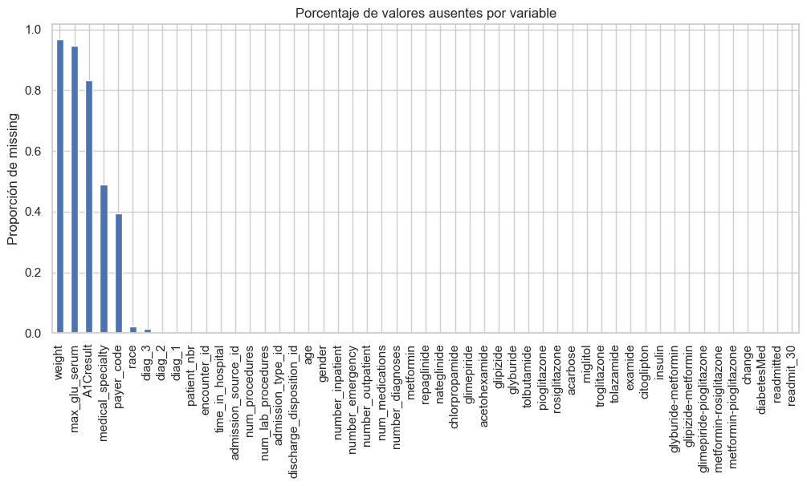

```python
missing = df.isnull().mean().sort_values(ascending=False)

missing.plot(kind='bar', figsize=(12,5))
plt.title("Porcentaje de valores ausentes por variable")
plt.ylabel("Proporción de missing")
plt.show()
```

```python
cols = ['race', 'payer_code', 'medical_specialty', 'weight']

for col in cols:
    print(f"{col}: {df[col].isnull().mean():.2%}")
```

```
race: 2.23%
payer_code: 39.56%
medical_specialty: 49.08%
weight: 96.86%
```

## Conclusiones sobre valores ausentes

El análisis de valores ausentes revela una distribución altamente heterogénea entre las variables del dataset, con la coexistencia de variables completamente informadas y otras con niveles de missing extremadamente elevados. Este patrón no parece aleatorio, sino que responde a características estructurales del proceso de recogida de datos clínico-administrativos.

En primer lugar, destacan varias variables con una proporción de valores ausentes superior al 80%, como `weight` (96,86%), `max_glu_serum` (94,75%) y `A1Cresult` (83,28%). Estos niveles de missing hacen inviable su imputación sin introducir un alto grado de incertidumbre y potencial sesgo, especialmente considerando que la ausencia de estos valores probablemente no es aleatoria, sino dependiente de la práctica clínica (por ejemplo, pruebas que solo se realizan en determinados perfiles de pacientes). En consecuencia, estas variables se consideran candidatas a exclusión del modelo.

En un segundo nivel, variables como `medical_specialty` (49,08%) y `payer_code` (39,56%) presentan un volumen significativo de valores ausentes. Aunque su eliminación no es tan evidente como en el caso anterior, su inclusión requeriría estrategias de imputación complejas o la creación de categorías específicas para valores desconocidos. Además, su elevada cardinalidad y naturaleza administrativa pueden limitar su capacidad predictiva real, por lo que su uso deberá evaluarse empíricamente en fases posteriores del modelado.

Por otro lado, variables como `race` (2,23%) y los diagnósticos secundarios (`diag_2`, `diag_3`) presentan un bajo porcentaje de valores ausentes, lo que permite su conservación mediante técnicas de imputación simples o tratamiento como categoría adicional. En estos casos, el impacto sobre el modelo se considera limitado.

Finalmente, un conjunto relevante de variables clave para el análisis —incluyendo identificadores (`patient_nbr`, `encounter_id`), variables demográficas (`age`, `gender`) y variables clínicas y administrativas principales (`time_in_hospital`, `num_procedures`, `num_lab_procedures`, `admission_type_id`, `discharge_disposition_id`)— no presentan valores ausentes. Esta característica refuerza la viabilidad del dataset para el desarrollo del modelo, ya que garantiza la disponibilidad completa de variables fundamentales para la predicción.

En conjunto, el patrón de valores ausentes sugiere que el missing no es completamente aleatorio (MNAR), sino condicionado por decisiones clínicas y procesos administrativos. Este hecho introduce un riesgo potencial de sesgo si no se trata adecuadamente. Por ello, el enfoque adoptado priorizará la eliminación de variables con missing extremo, el tratamiento cuidadoso de variables con missing moderado y la conservación de aquellas con baja proporción de valores ausentes, garantizando así un equilibrio entre calidad de los datos y capacidad predictiva del modelo.

## Identificación de variables problemáticas

Se analiza la cardinalidad de las variables para identificar:

- Variables con demasiados valores únicos (alta cardinalidad)
- Posibles identificadores (IDs) sin valor predictivo
- Variables redundantes o poco informativas

```python
high_cardinality = df.nunique().sort_values(ascending=False)
high_cardinality.head(15)
```

```
encounter_id                101766
patient_nbr                  71518
diag_3                         789
diag_2                         748
diag_1                         716
num_lab_procedures             118
num_medications                 75
medical_specialty               72
number_outpatient               39
number_emergency                33
discharge_disposition_id        26
number_inpatient                21
admission_source_id             17
payer_code                      17
number_diagnoses                16
dtype: int64
```

## Conclusiones sobre la cardinalidad de variables

El análisis de cardinalidad revela una estructura heterogénea en las variables del dataset, con diferencias significativas entre identificadores, variables clínicas y variables administrativas. Este aspecto es especialmente relevante, ya que la alta cardinalidad influye directamente en la estrategia de preprocesamiento, la dimensionalidad del modelo y el riesgo de sobreajuste.

En primer lugar, se identifican variables con cardinalidad extremadamente alta, como `encounter_id` (101.766 valores únicos) y `patient_nbr` (71.518 valores únicos). La primera actúa como identificador único de episodio y no aporta información predictiva, por lo que debe ser eliminada del proceso de modelado. La segunda, aunque también altamente única, sí puede aportar valor al permitir la reconstrucción de la trayectoria del paciente, especialmente si se agregan variables derivadas como número de ingresos previos o frecuencia de hospitalización.

En segundo lugar, las variables diagnósticas (`diag_1`, `diag_2`, `diag_3`) presentan una cardinalidad elevada (entre 700 y 789 categorías únicas), lo que refleja la gran diversidad de patologías registradas. Esta característica supone un reto importante para su tratamiento, ya que una codificación directa (one-hot encoding) resultaría en una explosión dimensional. Por ello, será necesario aplicar estrategias de agrupación clínica (por ejemplo, agrupación por capítulos ICD o categorías diagnósticas de alto nivel) o técnicas de reducción de dimensionalidad.

En un nivel intermedio de cardinalidad se encuentran variables como `medical_specialty` (72 categorías), `num_lab_procedures` (118 valores distintos) y `num_medications` (75 valores distintos). En el caso de `medical_specialty`, la alta diversidad combinada con el elevado porcentaje de valores ausentes previamente identificado limita su utilidad directa, aunque podría conservarse mediante agrupaciones en categorías clínicas más amplias. Las variables numéricas discretas, aunque presentan múltiples valores únicos, conservan interpretabilidad y potencial predictivo, por lo que no requieren transformación categórica estricta.

Finalmente, variables como `number_outpatient`, `number_emergency`, `number_inpatient`, `admission_source_id` o `payer_code` presentan cardinalidades moderadas. En estos casos, su tratamiento dependerá de su relevancia predictiva y del grado de ruido o redundancia que introduzcan en el modelo. En particular, `payer_code` ya había mostrado problemas significativos de valores ausentes, lo que reduce su prioridad como variable explicativa.

En conjunto, el análisis de cardinalidad confirma la presencia de un conjunto mixto de variables: algunas claramente identificadoras y descartables, otras con alto valor informativo pero alta complejidad de tratamiento, y un grupo intermedio que requerirá decisiones de ingeniería de variables. Este escenario refuerza la necesidad de un enfoque de preprocesamiento cuidadosamente diseñado, especialmente orientado a la reducción de dimensionalidad y a la preservación de la interpretabilidad del modelo.

## Análisis de variables numéricas relevantes

Se seleccionan variables numéricas relacionadas con la utilización de recursos hospitalarios y la complejidad clínica del paciente.

Estas variables han sido identificadas en la literatura como potencialmente predictivas del reingreso hospitalario.

Se analizan sus distribuciones para detectar:

- Asimetrías (skewness)
- Valores atípicos (outliers)
- Escalas heterogéneas

Este análisis permite anticipar la necesidad de transformaciones o normalización en fases posteriores.

```python
num_cols_numeric = [
    'time_in_hospital',
    'num_lab_procedures',
    'num_medications',
    'number_inpatient',
    'number_emergency',
    'number_outpatient'
]
```

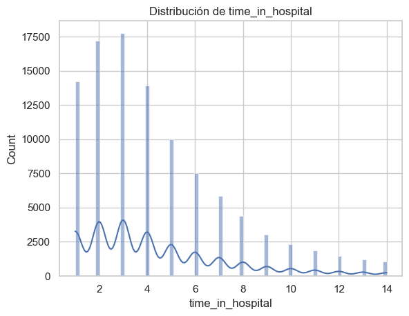

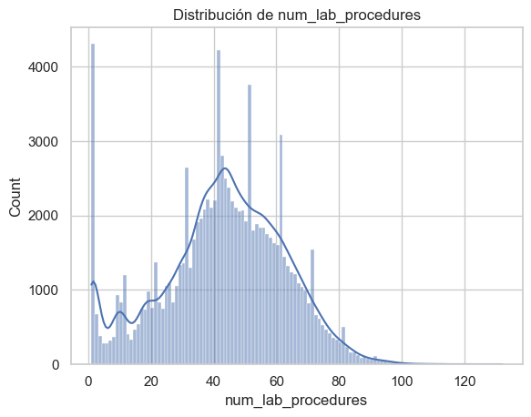

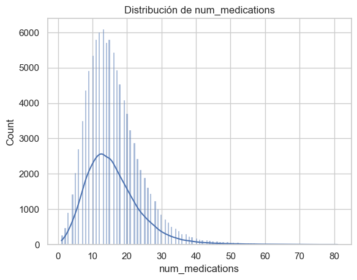

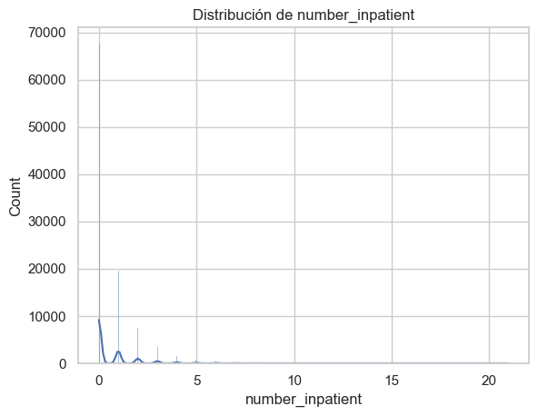

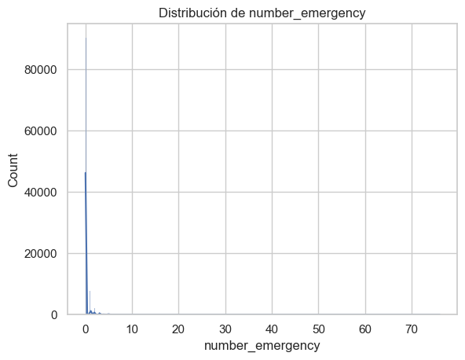

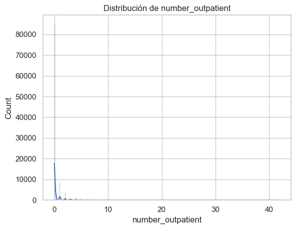

```python
for col in num_cols_numeric:
    plt.figure()
    sns.histplot(df[col], kde=True)
    plt.title(f"Distribución de {col}")
    plt.show()
```

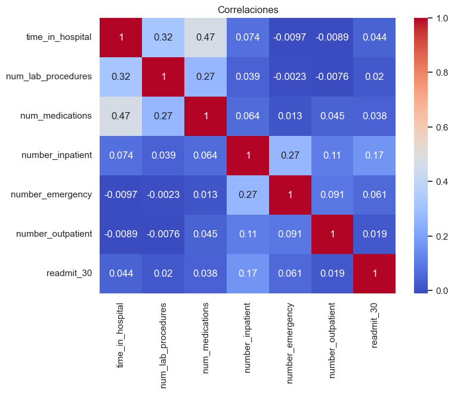

```python
corr = df[num_cols_numeric + ['readmit_30']].corr()

plt.figure(figsize=(8,6))
sns.heatmap(corr, annot=True, cmap="coolwarm")
plt.title("Correlaciones")
plt.show()
```

## Conclusiones sobre la correlación entre variables numéricas y la variable objetivo

El análisis de la matriz de correlación entre variables numéricas y la variable objetivo (`readmit_30`) muestra, en términos generales, una ausencia de relaciones lineales fuertes, lo cual es consistente con la naturaleza compleja y multifactorial del problema de predicción de reingresos hospitalarios.

En relación con las variables de utilización de recursos hospitalarios, se observa que `time_in_hospital` presenta correlaciones moderadas con `num_medications` (0.47) y `num_lab_procedures` (0.32), lo que sugiere que los pacientes con estancias más prolongadas tienden a requerir mayor intensidad de tratamiento y un mayor volumen de pruebas diagnósticas. Sin embargo, estas relaciones no se trasladan de forma directa a la variable objetivo, ya que su correlación con `readmit_30` es baja (0.044), lo que indica que la duración de la estancia hospitalaria, por sí sola, no es un predictor lineal fuerte del reingreso temprano.

De forma similar, `num_lab_procedures` muestra una correlación moderada con `num_medications` (0.27), pero su relación con la variable objetivo es igualmente débil (0.02). Esto sugiere que el volumen de pruebas realizadas durante el ingreso refleja complejidad clínica, pero no necesariamente se asocia de manera directa con la probabilidad de reingreso en 30 días.

La variable `num_medications` tampoco presenta una relación significativa con el objetivo (0.038), lo que refuerza la idea de que la intensidad terapéutica durante el ingreso no es suficiente por sí sola para explicar el riesgo de reingreso, al menos desde una perspectiva lineal.

En cuanto a las variables de utilización previa del sistema sanitario, `number_inpatient` destaca como la variable con mayor correlación con la variable objetivo (0.17), aunque sigue siendo relativamente baja en términos absolutos. Este resultado es coherente con la literatura, ya que los ingresos previos suelen ser uno de los predictores más relevantes del riesgo de reingreso, aunque su relación no necesariamente es lineal. `number_emergency` muestra una correlación moderada con `number_inpatient` (0.27), lo que sugiere que ambos indicadores reflejan patrones de alta utilización de recursos sanitarios, posiblemente asociados a pacientes con mayor fragilidad clínica. Sin embargo, su relación directa con `readmit_30` es igualmente limitada (0.061).

En conjunto, los resultados de la matriz de correlación indican que no existen relaciones lineales fuertes entre las variables numéricas y el reingreso a 30 días. Esto sugiere que el problema es inherentemente no lineal y que el uso de modelos capaces de capturar interacciones complejas entre variables (como Random Forest o Gradient Boosting) será más adecuado que enfoques puramente lineales. Asimismo, refuerza la importancia del feature engineering y de la incorporación de variables derivadas, ya que las señales predictivas parecen residir en relaciones multivariantes más complejas que no son capturadas por correlaciones bivariadas simples.

## Análisis de variables categóricas

Se examinan variables categóricas relevantes, como edad, género, tipo de ingreso y tipo de alta.

Este análisis permite:

- Identificar distribuciones desbalanceadas
- Detectar categorías poco frecuentes
- Evaluar la necesidad de agrupación o simplificación

Las variables categóricas en este dataset presentan retos importantes, como alta cardinalidad y posibles inconsistencias en la codificación.

```python
cat_cols = [
    'race',
    'gender',
    'age',
    'admission_type_id',
    'discharge_disposition_id'
]
```

```python
for col in cat_cols:
    print(df[col].value_counts().head(10))
    print("\n")
```

```
race
Caucasian          76099
AfricanAmerican    19210
Hispanic            2037
Other               1506
Asian                641
Name: count, dtype: int64


gender
Female             54708
Male               47055
Unknown/Invalid        3
Name: count, dtype: int64


age
[70-80)     26068
[60-70)     22483
[50-60)     17256
[80-90)     17197
[40-50)      9685
[30-40)      3775
[90-100)     2793
[20-30)      1657
[10-20)       691
[0-10)        161
Name: count, dtype: int64


admission_type_id
1    53990
3    18869
2    18480
6     5291
5     4785
8      320
7       21
4       10
Name: count, dtype: int64


discharge_disposition_id
1     60234
3     13954
6     12902
18     3691
2      2128
22     1993
11     1642
5      1184
25      989
4       815
Name: count, dtype: int64
```

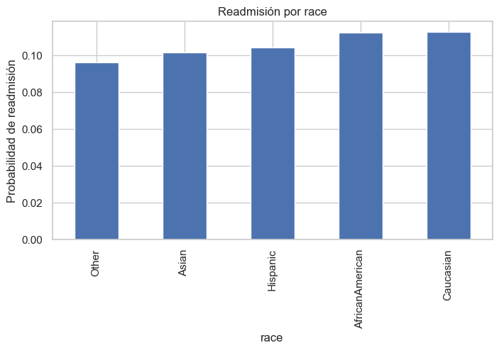

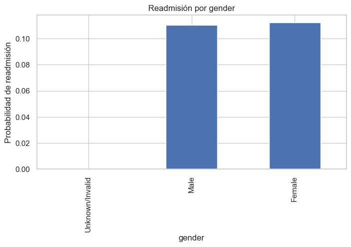

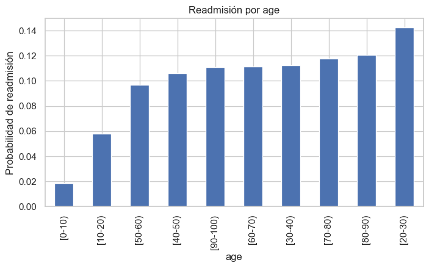

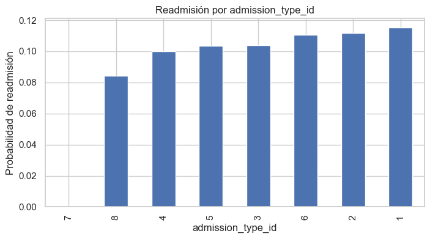

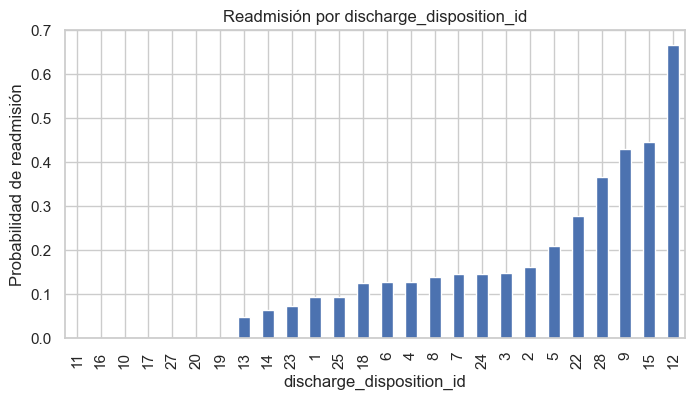

```python
for col in cat_cols:
    plt.figure(figsize=(8,4))
    df.groupby(col)['readmit_30'].mean().sort_values().plot(kind='bar')
    plt.title(f"Readmisión por {col}")
    plt.ylabel("Probabilidad de readmisión")
    plt.show()
```

## Conclusiones sobre variables categóricas y su relación con la variable objetivo

El análisis de la relación entre variables categóricas y la variable objetivo (`readmit_30`) permite identificar patrones diferenciales en la probabilidad de reingreso hospitalario, aunque en la mayoría de los casos las diferencias observadas son moderadas y no deterministas.

En primer lugar, las variables demográficas como `race` y `gender` muestran una variabilidad reducida en la tasa de reingreso. En el caso de la raza, las diferencias entre grupos son leves, situándose todas las categorías en un rango aproximado entre 0.096 y 0.113. Esto sugiere que, al menos en este dataset, la variable raza no presenta una capacidad discriminativa relevante para la predicción del reingreso temprano. De forma similar, la variable género muestra tasas prácticamente idénticas entre hombres y mujeres (≈0.11), lo que indica una ausencia de efecto diferenciador significativo. El valor nulo asociado a la categoría "Unknown/Invalid" se debe a una frecuencia marginal y no aporta información sustantiva.

La variable `admission_type_id` presenta diferencias limitadas entre categorías, con valores relativamente próximos entre sí. Destaca la categoría 8, con una tasa ligeramente inferior, aunque en general no se observan patrones consistentes que permitan establecer una relación fuerte entre el tipo de ingreso y el reingreso a 30 días. Esto sugiere que esta variable, en su forma actual, podría tener un valor predictivo limitado si no se transforma o agrupa adecuadamente.

Por el contrario, `discharge_disposition_id` muestra una heterogeneidad mucho más marcada. Existen categorías con tasas de reingreso muy elevadas (por ejemplo, valores superiores a 0.30 o incluso 0.40 en algunas categorías) frente a otras con valores prácticamente nulos. Esta variabilidad indica que el tipo de alta hospitalaria es una de las variables con mayor capacidad discriminativa dentro del conjunto analizado. Sin embargo, también se observa que algunas categorías tienen frecuencias muy bajas o comportamiento extremo, lo que podría introducir inestabilidad en el modelado si no se realiza una agrupación adecuada.

En conjunto, estos resultados evidencian que las variables categóricas analizadas presentan un comportamiento heterogéneo en relación con la variable objetivo. Mientras que variables como raza o género aportan escasa información predictiva, otras como edad y, especialmente, tipo de alta, muestran señales más relevantes. No obstante, en todos los casos se observa que las diferencias no son suficientemente fuertes como para generar reglas deterministas, lo que refuerza la necesidad de utilizar modelos multivariantes capaces de capturar interacciones complejas entre variables en lugar de relaciones univariadas simples.

## Importancia preliminar de variables

Se entrena un modelo exploratorio para estimar la importancia relativa de las variables numéricas.

Este análisis tiene carácter orientativo y permite:

- Identificar variables potencialmente relevantes
- Detectar variables con bajo valor predictivo
- Guiar el proceso de selección de características

Es importante destacar que esta importancia no debe interpretarse como causalidad, sino como una medida de asociación dentro del modelo utilizado.

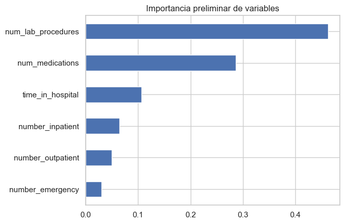

```python
from sklearn.ensemble import RandomForestClassifier

df_model = df[num_cols_numeric + ['readmit_30']].dropna()

X = df_model.drop('readmit_30', axis=1)
y = df_model['readmit_30']

model = RandomForestClassifier(n_estimators=100, random_state=42)
model.fit(X, y)

importances = pd.Series(model.feature_importances_, index=X.columns)

importances.sort_values().plot(kind='barh')
plt.title("Importancia preliminar de variables")
plt.show()
```

## Conclusiones sobre variables numéricas y categóricas en el análisis exploratorio

El análisis de las variables numéricas más relevantes (`num_lab_procedures`, `num_medications` y `time_in_hospital`) muestra patrones consistentes con la complejidad asistencial del episodio hospitalario, aunque con una capacidad predictiva limitada cuando se analizan de forma aislada respecto a la variable objetivo.

En primer lugar, `time_in_hospital` se posiciona como la variable con mayor relevancia conceptual dentro de este grupo, ya que refleja directamente la duración del episodio de ingreso. Su comportamiento sugiere que estancias más prolongadas se asocian con una mayor intensidad asistencial, lo cual se refleja también en su relación con `num_medications` y `num_lab_procedures`. Sin embargo, esta mayor complejidad del episodio no se traduce necesariamente en una mayor probabilidad de reingreso a 30 días, lo que indica que la severidad del ingreso no es un predictor lineal directo del evento objetivo.

Por su parte, `num_medications` y `num_lab_procedures` presentan una relación moderada con la duración de la estancia, lo que es coherente con la lógica clínica de mayor consumo de recursos en pacientes con mayor complejidad. No obstante, su capacidad explicativa individual respecto al reingreso es limitada, lo que refuerza la hipótesis de que el fenómeno de readmisión no depende únicamente de la intensidad del tratamiento durante el ingreso, sino de factores más complejos y posiblemente interdependientes.

En conjunto, las variables numéricas analizadas aportan información relevante sobre la carga asistencial del episodio, pero no presentan por sí solas una relación fuerte con la variable objetivo. Esto refuerza la necesidad de modelos capaces de capturar interacciones no lineales entre variables.

En consecuencia, el análisis exploratorio confirma que el problema de predicción de reingreso hospitalario presenta una estructura compleja, donde la señal predictiva no reside en variables individuales aisladas, sino en la combinación e interacción de múltiples factores clínicos, administrativos y demográficos.

## Conclusiones generales del análisis exploratorio de datos (EDA)

El análisis exploratorio realizado sobre el conjunto de datos permite extraer una serie de conclusiones relevantes tanto desde el punto de vista descriptivo como metodológico, que condicionan directamente el diseño del modelo predictivo posterior.

En primer lugar, se observa que el dataset presenta una estructura compleja, con una combinación de variables demográficas, clínicas, administrativas y de utilización de recursos sanitarios. Esta heterogeneidad es característica de datos procedentes de entornos hospitalarios reales y refuerza la necesidad de un enfoque de modelado multivariante.

En relación con la calidad de los datos, se identifican distintos niveles de valores ausentes, con especial concentración en variables como `weight`, `medical_specialty` y `payer_code`, lo que introduce un reto importante de preprocesamiento. Estas ausencias no son homogéneas ni aleatorias en todos los casos, lo que puede implicar sesgos de registro y la necesidad de estrategias específicas de imputación, agrupación o incluso eliminación de variables en función de su utilidad predictiva.

El análisis de cardinalidad muestra la existencia de variables de alta granularidad, como identificadores de pacientes y episodios (`patient_nbr`, `encounter_id`), así como variables clínicas codificadas (`diag_1`, `diag_2`, `diag_3`). Este hecho refuerza la necesidad de un tratamiento cuidadoso de las variables categóricas, ya que su codificación directa puede generar alta dimensionalidad y problemas de generalización.

Desde el punto de vista de la variable objetivo, se identifica un claro desbalance de clases, con una proporción significativamente mayor de pacientes no reingresados frente a los reingresados en menos de 30 días. Este desbalance tiene implicaciones directas en la fase de modelado, ya que puede inducir sesgos hacia la clase mayoritaria si no se aplican técnicas específicas de mitigación.

El análisis de correlaciones entre variables numéricas muestra una ausencia de relaciones lineales fuertes con la variable objetivo, lo que sugiere que el problema no puede ser abordado adecuadamente mediante modelos lineales simples. En su lugar, se justifica el uso de modelos capaces de capturar relaciones no lineales e interacciones complejas entre variables.

Por otro lado, el análisis de variables categóricas revela diferencias moderadas en la tasa de reingreso entre ciertas categorías, especialmente en variables relacionadas con el tipo de alta hospitalaria, mientras que otras variables demográficas como raza o género presentan un poder discriminativo limitado. Esto indica que la señal predictiva se concentra en un subconjunto específico de variables y no está distribuida de forma uniforme en todo el dataset.

En conjunto, el EDA permite concluir que el problema de predicción de reingreso hospitalario a 30 días presenta las siguientes características clave:

- Alta heterogeneidad en los tipos de variables disponibles.
- Presencia de valores ausentes no triviales en variables relevantes.
- Desbalance significativo en la variable objetivo.
- Baja linealidad en la relación entre variables y objetivo.
- Existencia de señales predictivas débiles pero combinables.

Estas características justifican el uso de un pipeline de machine learning basado en preprocesamiento intensivo, transformación de variables categóricas, tratamiento del desbalanceo de clases y utilización de modelos no lineales como Random Forest o Gradient Boosting.

Finalmente, el EDA confirma que el valor predictivo del dataset no reside en variables individuales aisladas, sino en la interacción conjunta entre múltiples factores clínicos y administrativos, lo que refuerza la pertinencia del enfoque metodológico propuesto en este trabajo.